# ms2hw1_q4

Na SeungChan

2023-09-15

# Question 4

## (a)

```r
mme_unif <- function(n, a, b){
  x <- runif(n, a, b)
  t1 <- mean(x) - sqrt(3) * sd(x)
  t2 <- mean(x) + sqrt(3) * sd(x)
  c(t1, t2)
}
```

runif(n, t1, t2)는 unif(t1, t2)를 따르는 확률변수 X를 따라 n회 시행한 결과를 추출하는, 즉 시행의 결과 나오는 n*1 vector가 X1, X2, …, Xn에 대응되는 R 함수이다. 이를 기반으로 mme_unif(n, a, b) 함수를 정의하였다. 이는 모수가 (a,b)인 균등분포를 따르는 확률분포 X로부터 n회 mme를 시행하여 도출되는 theta1과 theta2의 mme를 return하는 함수이다.

```r
mmes_n3 <- tibble()
for (i in 1:100) {
  mmes_n3 = rbind(mmes_n3, c(i, mme_unif(3,2,7)))
}
colnames(mmes_n3) <- c('samplename', 'theta1', 'theta2')
mmes_n3
```

| samplename | theta1 | theta2 |
| --- | --- | --- |
| 1 | 2.3629093 | 8.763827 |
| 2 | 3.9605476 | 6.677083 |
| 3 | 1.7154064 | 7.378751 |
| 4 | 3.8633438 | 6.409719 |
| 5 | 1.7388060 | 7.769174 |
| 6 | 1.1814633 | 9.604298 |
| 7 | 3.2654141 | 7.199123 |
| 8 | 1.3077378 | 9.606496 |
| 9 | 1.7195050 | 5.570004 |
| 10 | 3.5069444 | 7.788762 |

[output cut: 90 more lines]

mme2_n3은 theta1과 theta2 각각의 mme 추정량 100개를 저장한 tibble이다. 문제의 조건상 서로 다른 sample에 대해 각각 theta1과 theta2를 구하는 별도의 작업을 하는 것이 허용되지 않아 이와 같이 작업하였다.

## (b)

앞서 구한 theta_j1의 극한분포는 normal distribution이고 평균은 MME for theta1, 분산은 2((theta2 - theta1)^2)/15n = 10/9이다. 이에 따라 분산의 그래프를 그리면 다음과 같다.

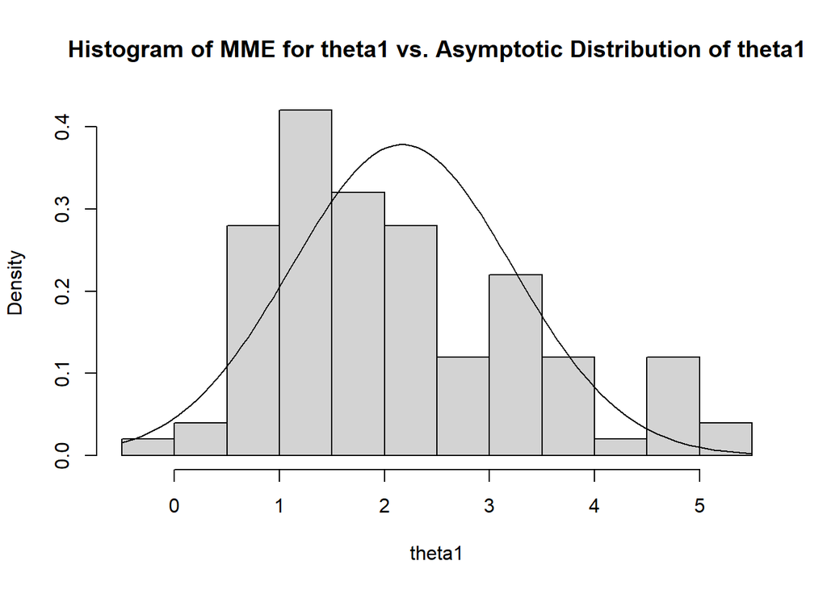

```r
est_t1 <- mean(mmes_n3$theta1)
hist(mmes_n3$theta1, probability = T, main = 'Histogram of MME for theta1 vs. Asymptotic Distribution of theta1', xlab = 'theta1')
curve(dnorm(x, est_t1, sqrt(10)/3), add = T)
```

평균 부분의 차이가 있지만 n=3임을 고려하면 비슷해질 가능성이 있다.

## (c)

앞서 구한 theta_j2의 극한분포는 normal distribution이고 평균은 MME for theta2, 분산은 2((theta2 - theta1)^2)/15n = 10/9이다. 이에 따라 분산의 그래프를 그리면 다음과 같다.

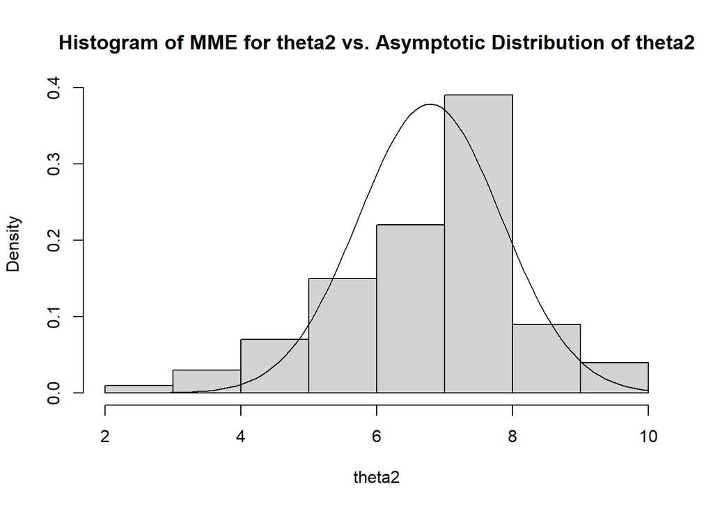

```r
est_t2 <- mean(mmes_n3$theta2)
hist(mmes_n3$theta2, probability = T, main = 'Histogram of MME for theta2 vs. Asymptotic Distribution of theta2', xlab = 'theta2')
curve(dnorm(x, est_t2, sqrt(10)/3), add = T)
```

마찬가지로, 평균 부분의 차이가 있지만 n=3임을 고려하면 비슷해 보인다.

## (d)

여기서부터는, 앞서 제시된 모수 theta1, theta2의 값을 모르는 상태에서 신뢰구간을 통해 추정한다고 가정한다.(안다면 추정하는 의미가 없다.) 따라서, CI의 양 끝값에 있는 모수 theta1, theta2를 적절히 처리해야 하는데, 가장 간단한 방법은 theta1의 MME가 theta1으로, theta2의 MME가 theta2로 확률수렴한다는 사실을 통해 양 끝점의 theta1, theta2 자리에 theta1의 MME, theta2의 MME를 plug in하는 것이다. 해당 문제에서는 이에 따라 각 문제의 CI를 계산할 때 사용될 분산을 MME 추정량으로부터 계산하였다.

```r
mmes_n3 <- mmes_n3 %>%
    mutate(se = sqrt(2*(theta2-theta1)^2/(15*3)), er = se*qnorm(0.95), t1_CILB = theta1 - er, t1_CIUB = theta1 + er, t2_CILB = theta2 - er, t2_CIUB = theta2 + er)
mmes_n3
```

| samplename | theta1 | theta2 | se | er | t1_CILB | t1_CIUB | t2_CILB | t2_CIUB |
| --- | --- | --- | --- | --- | --- | --- | --- | --- |
| 1 | 2.3629093 | 8.763827 | 1.3494320 | 2.2196181 | 0.1432912 | 4.582527 | 6.544209 | 10.983445 |
| 2 | 3.9605476 | 6.677083 | 0.5726959 | 0.9420009 | 3.0185466 | 4.902548 | 5.735082 | 7.619084 |
| 3 | 1.7154064 | 7.378751 | 1.1939378 | 1.9638530 | -0.2484466 | 3.679259 | 5.414898 | 9.342604 |
| 4 | 3.8633438 | 6.409719 | 0.5368230 | 0.8829953 | 2.9803485 | 4.746339 | 5.526724 | 7.292714 |
| 5 | 1.7388060 | 7.769174 | 1.2713131 | 2.0911240 | -0.3523179 | 3.829930 | 5.678050 | 9.860298 |
| 6 | 1.1814633 | 9.604298 | 1.7756894 | 2.9207492 | -1.7392859 | 4.102212 | 6.683549 | 12.525047 |
| 7 | 3.2654141 | 7.199123 | 0.8292987 | 1.3640750 | 1.9013391 | 4.629489 | 5.835048 | 8.563198 |
| 8 | 1.3077378 | 9.606496 | 1.7495318 | 2.8777238 | -1.5699860 | 4.185462 | 6.728772 | 12.484220 |
| 9 | 1.7195050 | 5.570004 | 0.8117565 | 1.3352207 | 0.3842843 | 3.054726 | 4.234784 | 6.905225 |
| 10 | 3.5069444 | 7.788762 | 0.9026865 | 1.4847871 | 2.0221573 | 4.991732 | 6.303975 | 9.273549 |

[output cut: 90 more lines]

## (e)

```r
mmes_n3_t1 <- mmes_n3 %>%
    mutate(contains_true = ifelse(t1_CILB < 2&t1_CIUB > 2, 1, 0))
mean(mmes_n3_t1$contains_true)
```

```
## [1] 0.77
```

따라서 신뢰구간 중 참값을 포함하는 것의 비율은 77%이다. 한편, 각 신뢰구간의 그림을 그려 보면 다음과 같다.

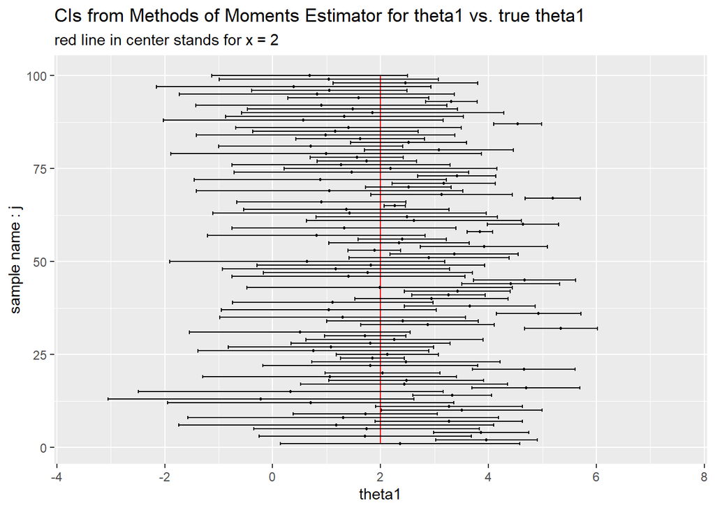

```r
ggplot(data = mmes_n3_t1, mapping = aes(y = samplename)) +
    geom_line(mapping = aes(x = 2), color = 'red') +
    xlim(-3.5, 7.5) +
    geom_errorbarh(mapping = aes(xmin = t1_CILB, xmax = t1_CIUB)) +
    geom_point(mapping = aes(x = theta1), size = 0.75) +
    labs(title = 'CIs from Methods of Moments Estimator for theta1 vs. true theta1',
         subtitle = 'red line in center stands for x = 2') +
    xlab('theta1') +
    ylab('sample name : j')
```

## (f)

```r
mmes_n3_t2 <- mmes_n3 %>%
    mutate(contains_true = ifelse(t2_CILB < 7&t2_CIUB > 7, 1, 0))
mean(mmes_n3_t2$contains_true)
```

```
## [1] 0.77
```

따라서 신뢰구간 중 참값을 포함하는 것의 비율은 77%이다. 한편, 각 신뢰구간의 그림을 그려 보면 다음과 같다.

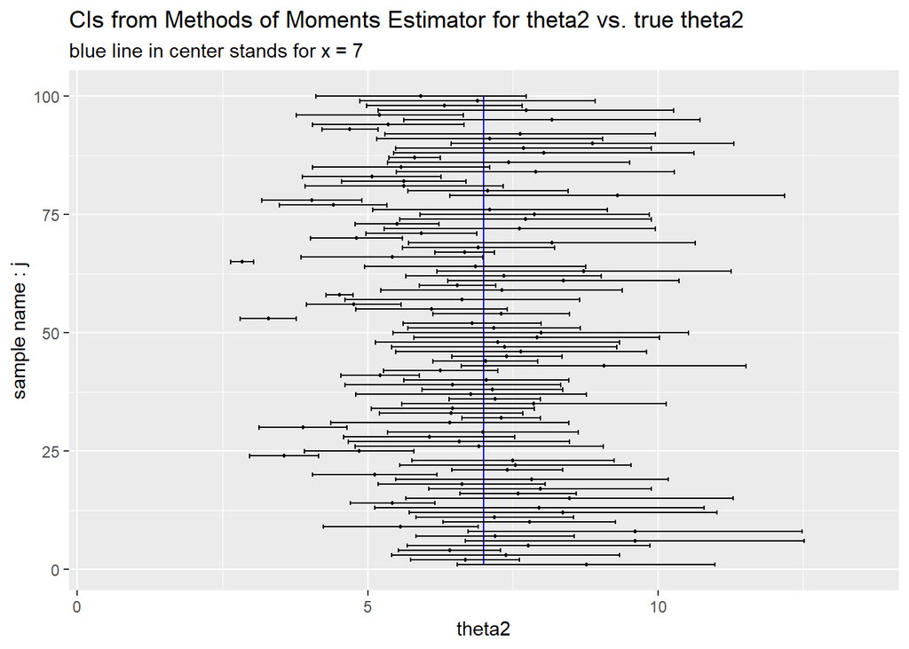

```r
ggplot(data = mmes_n3_t2, mapping = aes(y = samplename)) +
    geom_line(mapping = aes(x = 7), color = 'blue') +
    xlim(0.5, 13.5) +
    geom_errorbarh(mapping = aes(xmin = t2_CILB, xmax = t2_CIUB)) +
    geom_point(mapping = aes(x = theta2), size = 0.75) +
    labs(title = 'CIs from Methods of Moments Estimator for theta2 vs. true theta2',
         subtitle = 'blue line in center stands for x = 7') +
    xlab('theta2') +
    ylab('sample name : j')
```

## (g)

### n = 50 case

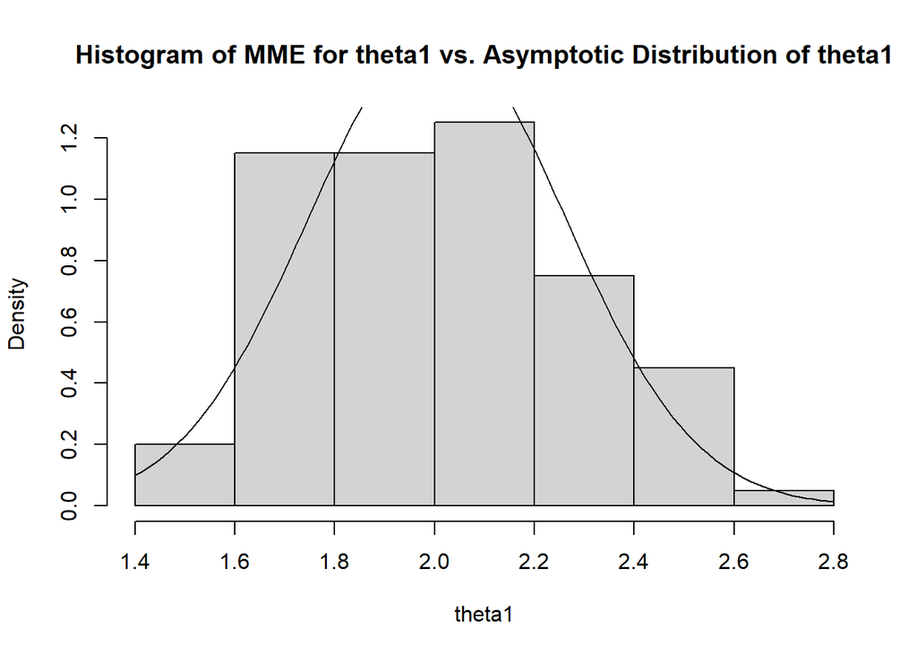

```r
mmes_n50 <- tibble()
for (i in 1:100) {
  mmes_n50 = rbind(mmes_n50, c(i, mme_unif(50,2,7)))
}
colnames(mmes_n50) <- c('samplename', 'theta1', 'theta2')

est_t1 <- mean(mmes_n50$theta1)
hist(mmes_n50$theta1, probability = T, main = 'Histogram of MME for theta1 vs. Asymptotic Distribution of theta1', xlab = 'theta1')
curve(dnorm(x, est_t1, sqrt(1/15)), add = T)
```

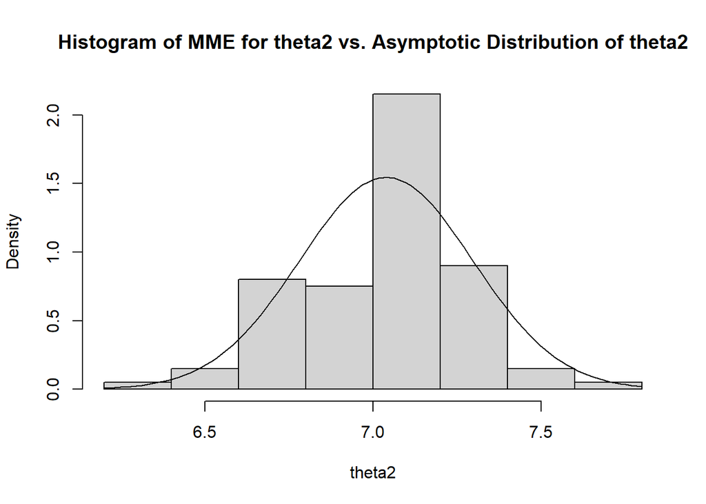

```r
est_t2 <- mean(mmes_n50$theta2)
hist(mmes_n50$theta2, probability = T, main = 'Histogram of MME for theta2 vs. Asymptotic Distribution of theta2', xlab = 'theta2')
curve(dnorm(x, est_t2, sqrt(1/15)), add = T)
```

```r
mmes_n50 <- mmes_n50 %>%
    mutate(se = sqrt(2*(theta2-theta1)^2/(15*50)), er = se*qnorm(0.95), t1_CILB = theta1 - er, t1_CIUB = theta1 + er, t2_CILB = theta2 - er, t2_CIUB = theta2 + er)

#theta1
mmes_n50_t1 <- mmes_n50 %>%
    mutate(contains_true = ifelse(t1_CILB < 2&t1_CIUB > 2, 1, 0))
mean(mmes_n50_t1$contains_true)
```

```
## [1] 0.88
```

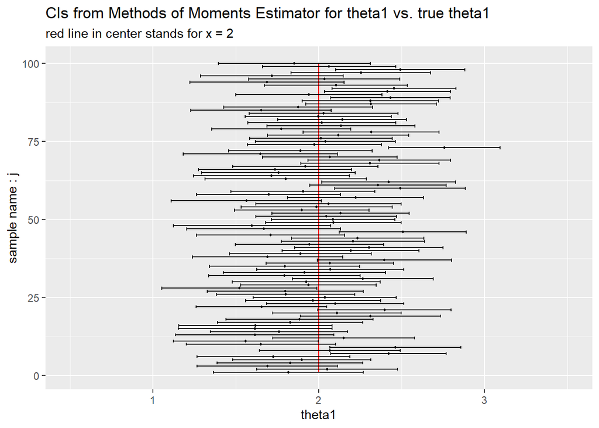

```r
ggplot(data = mmes_n50_t1, mapping = aes(y = samplename)) +
    geom_line(mapping = aes(x = 2), color = 'red') +
    xlim(0.5, 3.5) +
    geom_errorbarh(mapping = aes(xmin = t1_CILB, xmax = t1_CIUB)) +
    geom_point(mapping = aes(x = theta1), size = 0.75) +
    labs(title = 'CIs from Methods of Moments Estimator for theta1 vs. true theta1',
         subtitle = 'red line in center stands for x = 2') +
    xlab('theta1') +
    ylab('sample name : j')
```

```r
#theta2
mmes_n50_t2 <- mmes_n50 %>%
    mutate(contains_true = ifelse(t2_CILB < 7&t2_CIUB > 7, 1, 0))
mean(mmes_n50_t2$contains_true)
```

```
## [1] 0.93
```

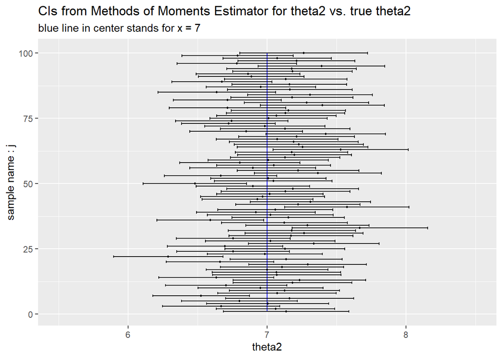

```r
ggplot(data = mmes_n50_t2, mapping = aes(y = samplename)) +
    geom_line(mapping = aes(x = 7), color = 'blue') +
    xlim(5.5, 8.5) +
    geom_errorbarh(mapping = aes(xmin = t2_CILB, xmax = t2_CIUB)) +
    geom_point(mapping = aes(x = theta2), size = 0.75) +
    labs(title = 'CIs from Methods of Moments Estimator for theta2 vs. true theta2',
         subtitle = 'blue line in center stands for x = 7') +
    xlab('theta2') +
    ylab('sample name : j')
```

### n = 100 case

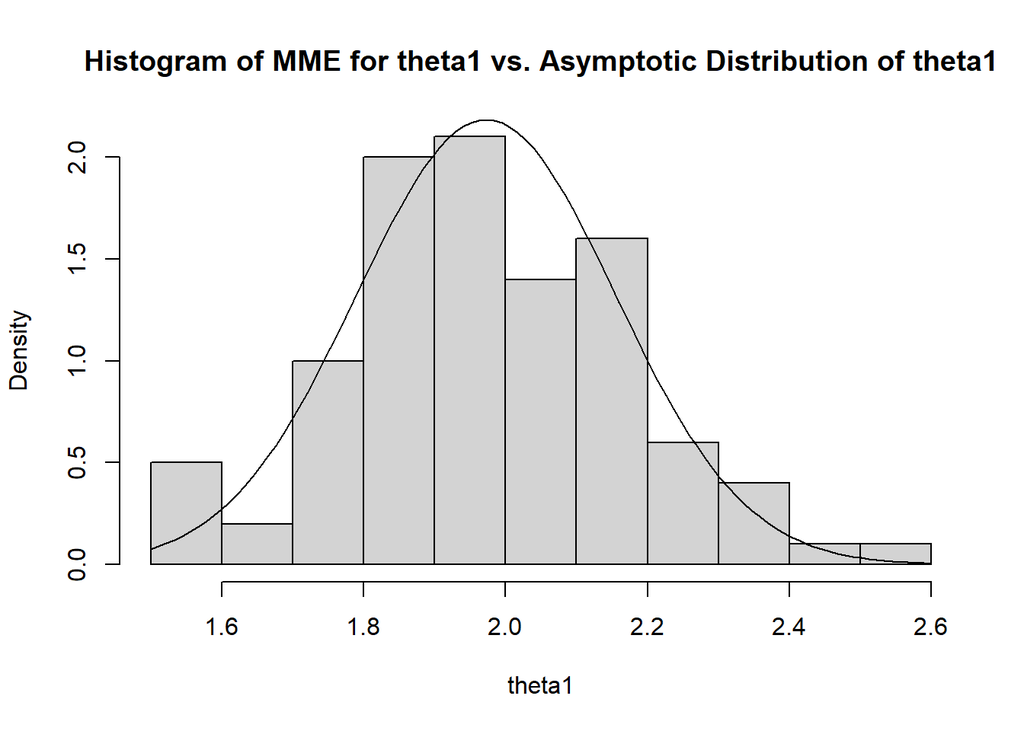

```r
mmes_n100 <- tibble()
for (i in 1:100) {
  mmes_n100 = rbind(mmes_n100, c(i, mme_unif(100,2,7)))
}
colnames(mmes_n100) <- c('samplename', 'theta1', 'theta2')

est_t1 <- mean(mmes_n100$theta1)
hist(mmes_n100$theta1, probability = T, main = 'Histogram of MME for theta1 vs. Asymptotic Distribution of theta1', xlab = 'theta1')
curve(dnorm(x, est_t1, sqrt(1/30)), add = T)
```

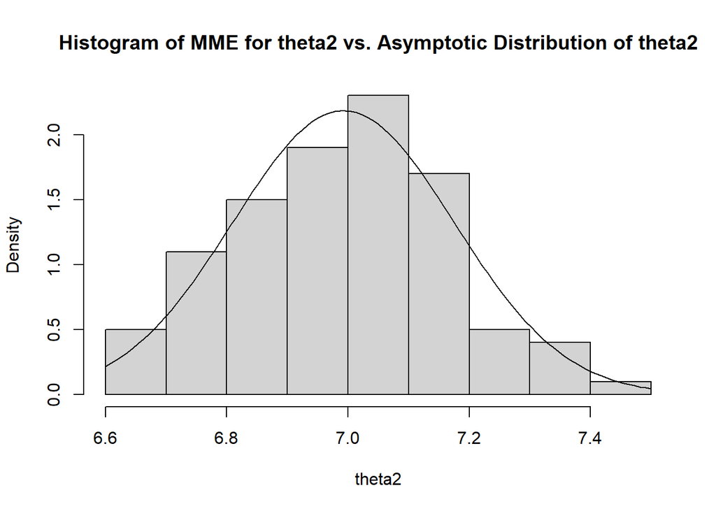

```r
est_t2 <- mean(mmes_n100$theta2)
hist(mmes_n100$theta2, probability = T, main = 'Histogram of MME for theta2 vs. Asymptotic Distribution of theta2', xlab = 'theta2')
curve(dnorm(x, est_t2, sqrt(1/30)), add = T)
```

```r
mmes_n100 <- mmes_n100 %>%
    mutate(se = sqrt(2*(theta2-theta1)^2/(15*100)), er = se*qnorm(0.95), t1_CILB = theta1 - er, t1_CIUB = theta1 + er, t2_CILB = theta2 - er, t2_CIUB = theta2 + er)

#theta1
mmes_n100_t1 <- mmes_n100 %>%
    mutate(contains_true = ifelse(t1_CILB < 2&t1_CIUB > 2, 1, 0))
mean(mmes_n100_t1$contains_true)
```

```
## [1] 0.86
```

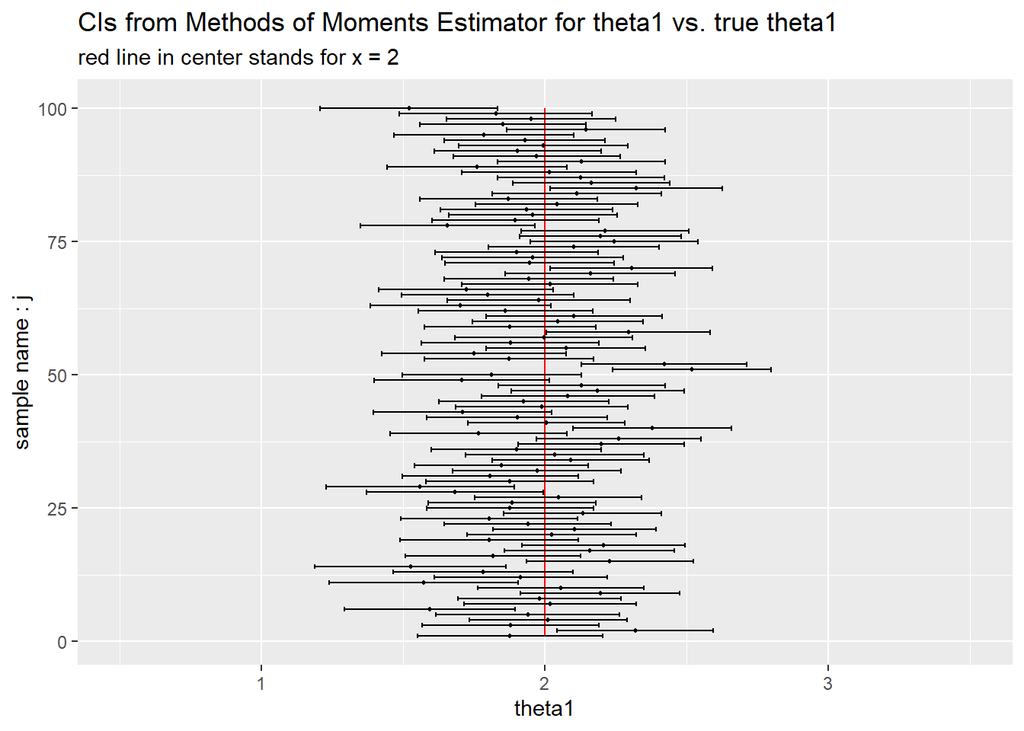

```r
ggplot(data = mmes_n100_t1, mapping = aes(y = samplename)) +
    geom_line(mapping = aes(x = 2), color = 'red') +
    xlim(0.5, 3.5) +
    geom_errorbarh(mapping = aes(xmin = t1_CILB, xmax = t1_CIUB)) +
    geom_point(mapping = aes(x = theta1), size = 0.75) +
    labs(title = 'CIs from Methods of Moments Estimator for theta1 vs. true theta1',
         subtitle = 'red line in center stands for x = 2') +
    xlab('theta1') +
    ylab('sample name : j')
```

```r
#theta2
mmes_n100_t2 <- mmes_n100 %>%
    mutate(contains_true = ifelse(t2_CILB < 7&t2_CIUB > 7, 1, 0))
mean(mmes_n100_t2$contains_true)
```

```
## [1] 0.9
```

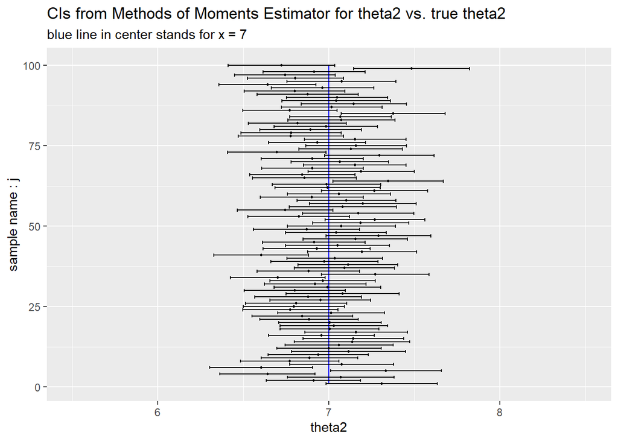

```r
ggplot(data = mmes_n100_t2, mapping = aes(y = samplename)) +
    geom_line(mapping = aes(x = 7), color = 'blue') +
    xlim(5.5, 8.5) +
    geom_errorbarh(mapping = aes(xmin = t2_CILB, xmax = t2_CIUB)) +
    geom_point(mapping = aes(x = theta2), size = 0.75) +
    labs(title = 'CIs from Methods of Moments Estimator for theta2 vs. true theta2',
         subtitle = 'blue line in center stands for x = 7') +
    xlab('theta2') +
    ylab('sample name : j')
```

### n = 200 case

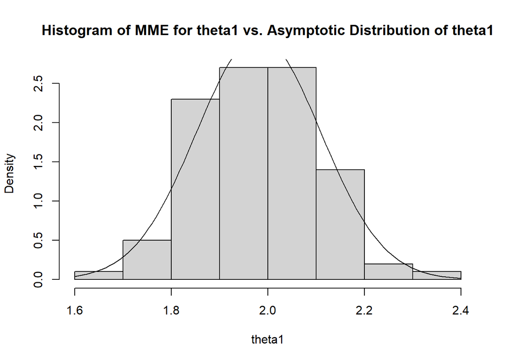

```r
mmes_n200 <- tibble()
for (i in 1:100) {
  mmes_n200 = rbind(mmes_n200, c(i, mme_unif(200,2,7)))
}
colnames(mmes_n200) <- c('samplename', 'theta1', 'theta2')

est_t1 <- mean(mmes_n200$theta1)
hist(mmes_n200$theta1, probability = T, main = 'Histogram of MME for theta1 vs. Asymptotic Distribution of theta1', xlab = 'theta1')
curve(dnorm(x, est_t1, sqrt(1/60)), add = T)
```

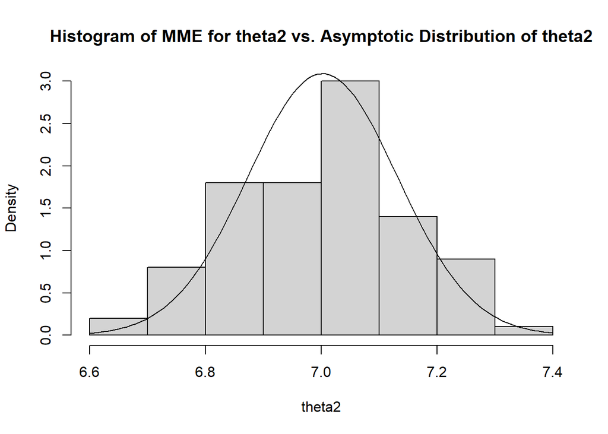

```r
est_t2 <- mean(mmes_n200$theta2)
hist(mmes_n200$theta2, probability = T, main = 'Histogram of MME for theta2 vs. Asymptotic Distribution of theta2', xlab = 'theta2')
curve(dnorm(x, est_t2, sqrt(1/60)), add = T)
```

```r
mmes_n200 <- mmes_n200 %>%
    mutate(se = sqrt(2*(theta2-theta1)^2/(15*200)), er = se*qnorm(0.95), t1_CILB = theta1 - er, t1_CIUB = theta1 + er, t2_CILB = theta2 - er, t2_CIUB = theta2 + er)

#theta1
mmes_n200_t1 <- mmes_n200 %>%
    mutate(contains_true = ifelse(t1_CILB < 2&t1_CIUB > 2, 1, 0))
mean(mmes_n200_t1$contains_true)
```

```
## [1] 0.94
```

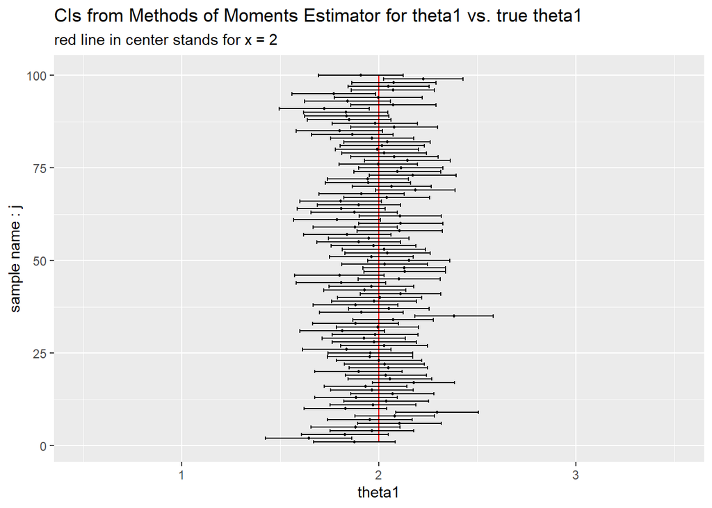

```r
ggplot(data = mmes_n200_t1, mapping = aes(y = samplename)) +
    geom_line(mapping = aes(x = 2), color = 'red') +
    xlim(0.5, 3.5) +
    geom_errorbarh(mapping = aes(xmin = t1_CILB, xmax = t1_CIUB)) +
    geom_point(mapping = aes(x = theta1), size = 0.75) +
    labs(title = 'CIs from Methods of Moments Estimator for theta1 vs. true theta1',
         subtitle = 'red line in center stands for x = 2') +
    xlab('theta1') +
    ylab('sample name : j')
```

```r
#theta2
mmes_n200_t2 <- mmes_n200 %>%
    mutate(contains_true = ifelse(t2_CILB < 7&t2_CIUB > 7, 1, 0))
mean(mmes_n200_t2$contains_true)
```

```
## [1] 0.82
```

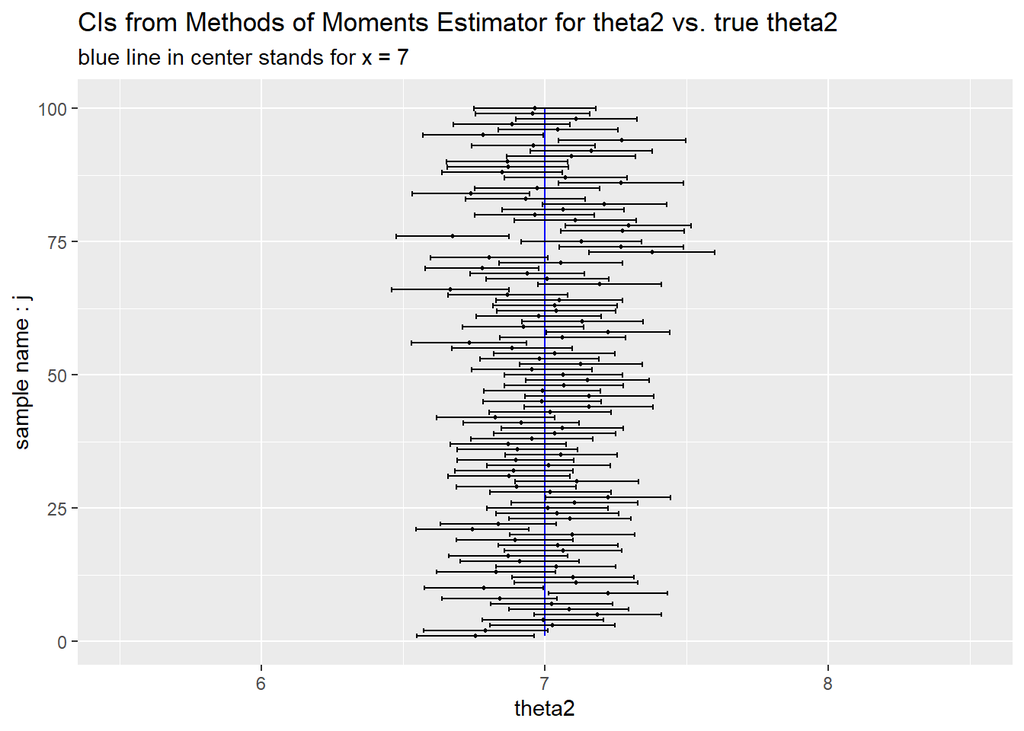

```r
ggplot(data = mmes_n200_t2, mapping = aes(y = samplename)) +
    geom_line(mapping = aes(x = 7), color = 'blue') +
    xlim(5.5, 8.5) +
    geom_errorbarh(mapping = aes(xmin = t2_CILB, xmax = t2_CIUB)) +
    geom_point(mapping = aes(x = theta2), size = 0.75) +
    labs(title = 'CIs from Methods of Moments Estimator for theta2 vs. true theta2',
         subtitle = 'blue line in center stands for x = 7') +
    xlab('theta2') +
    ylab('sample name : j')
```